# Statistiques Descriptives 2

Ibrahim BENKHERFELLAH & Axel COULET

2025-02-21

# Exercice 1

## 1

Tout d’abord, qu’est-ce qu’une variable explicative et une variable expliquée ?

- Une variable explicative est la variable qui permet d’expliquer une autre variable. Elle est souvent notée $X$. Sur une représentation graphique, la variable explicative est représentée en abscisse.
- Une variable expliquée est la variable pour laquelle on cherche un modèle de prévision. Son évolution dépend d’une ou de plusieurs autres variables. Elle est souvent notée $Y$. Sur une représentation graphique, la variable expliquée est représentée en ordonnée.

Ainsi, dans le cadre de notre exercice, la variable explicative est le **dosage de sérum X (en mL)**. Et la variable expliquée est la **quantité de bactéries Y (en UFC/mL)**, car c’est celle qui est mesurée en fonction du dosage de sérum et qui dépend potentiellement de $X$.

## 2

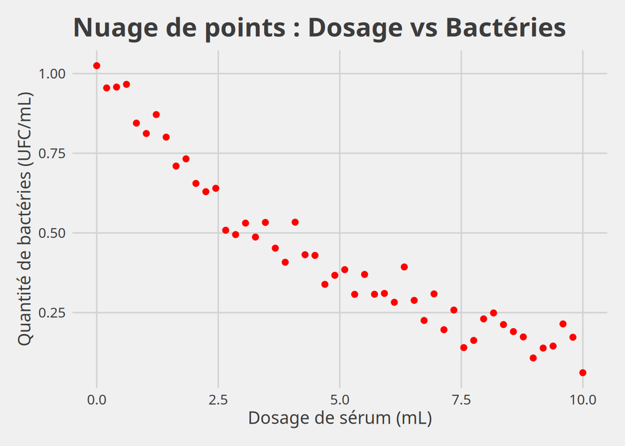

## 3

a)

- Moyenne de la quantité de bactéries : **$\overline{y} = 0.4389205$**
- Variance de la quantité de bactéries : **$Var(y) = 0.0684857$**

b) Box-plot de la dsitribution de la variable : **Quantité de bactéries**

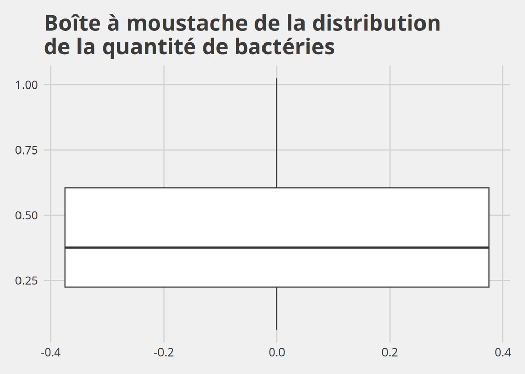

1. Analyse

Juste pour avoir des infos globales sur les variables

```
##        X              Y
##  Min.   : 0.0   Min.   :0.06142
##  1st Qu.: 2.5   1st Qu.:0.22651
##  Median : 5.0   Median :0.37733
##  Mean   : 5.0   Mean   :0.43892
##  3rd Qu.: 7.5   3rd Qu.:0.60555
##  Max.   :10.0   Max.   :1.02484
```